# Sei’s drum!

Michael Großbach

Draft 2020-07-30

```r
library(brms)
library(dplyr)
library(ggplot2)
library(ggthemes)
library(kfigr)
library(knitr)
# library(pander)
library(patchwork)
# library(tidyr)
```

The data set was read in as is, the columns `subj`, `arm`, `cond`, `series` and `no` were converted to factors, the column `filename` was deleted. A new column was added to the dataset, `patient`, based on the `subj` prefix (‘P’ or ‘S’), with a ‘0’ coding for healthy controls, and a ‘1’ for patients.

```r
read.csv("features.csv") %>%
  mutate(filename = NULL,
         patient = factor(if_else(grepl("^P",
                                        subj),
                                  1L,
                                  0L)),
         series = factor(series),
         subj = factor(subj),
         arm = factor(arm),
         cond = factor(cond),
         no = factor(no)) ->
  drum_beats
```

# 1 Exploration

## 1.1 Instruction Condition, and Arm Used

In a first attempt to get an overview, the descriptors’ density estimates were plotted, broken down by `arm` and `cond`.

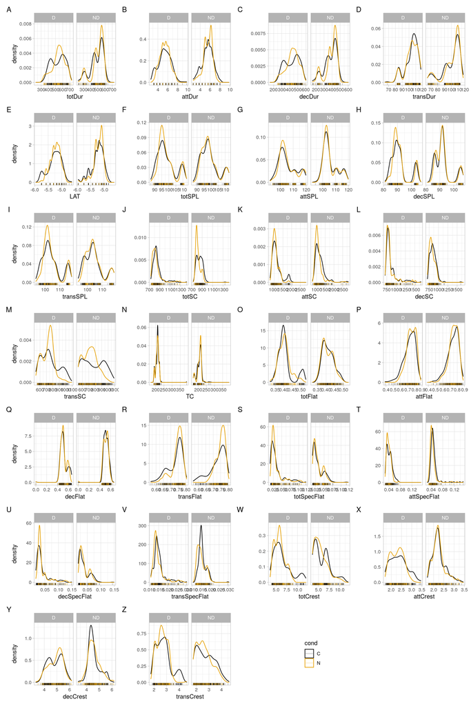

```r
dep_vars <- names(drum_beats)[which(!(names(drum_beats) %in% c("subj",
                                                               "arm",
                                                               "cond",
                                                               "no",
                                                               "series",
                                                               "patient")))]
n_vars <- length(dep_vars)
  plot_lst <- vector("list", length = n_vars)
  plt_cnt <- 1
  for (dv in dep_vars) {
    if (plt_cnt == n_vars) {
      plt_pos <- c(2, 0.5)
    } else {
      plt_pos <- "none"
    }
    if (plt_cnt %% 4 == 1) {
      ylab <- "density"
    } else {
      ylab <- ""
    }
    plot_lst[[plt_cnt]] <- ggplot(drum_beats,
                                  aes_string(x = dv,
                                             color = "cond")) +
      geom_density(na.rm = TRUE) +
      scale_color_colorblind() +
      ylab(ylab) +
      geom_rug(alpha = 0.25) +
      theme(legend.position = plt_pos) +
      facet_wrap(~ arm)
    plt_cnt <- plt_cnt + 1
  }
  print(wrap_plots(plot_lst,
                   ncol = 4) +
          plot_annotation(
            tag_levels = "A"))
```

Fig. 1. *Descriptor densities along with raw data points (rug ticks on x axes), broken down by arm (dominant [D] vs non-dominant [ND]) and instruction condition (controlled = C, normal = N).*

Several peculiarities are immediately apparent from the plots in Fig. 1:

- There are no substantial differences in the density distributions between normal (N) and controlled (C) strokes
- `attDur`, `LAT`, and `attFlat` have very few unique data values (see rug ticks at bottom of plots)
- Looking at the dominant arm alone (and excluding the vars `attDur`, `LAT`, and `attFlat` for the reason just mentioned), the densities have a trend toward a larger variance in the controlled condition (in other words: a less pointed distribution) with additional or larger humps in the tails, respectively

The lack of any clear-cut differences in the raw data between conditions suggests that it will be hard to find any differences by modeling.

The limited number of unique values in the attack-related measures (*e.g.* `attDur` only has 35 unique values in a total of 1102 observations across all subjects, conditions, and sides; that’s only 3 percent!) suggests that rounding errors propagated through the calculations. This is probably due to very similar, *i.e.* highly automated, and short attack times combined with the given sampling frequency, resulting in few data points, which in course of the calculations result in the observed phenomenon. But I’m just guessing here, as I do not know anything about these descriptors and how they are calculated or interpreted. Judging by the range of values of, *i.e.*, `attDur` (2.59, 9.8ms, across both sides and conditions) and a sampling frequency of 48 kHz, this leaves us at 48 * (9.8 - 2.59) = 346 points to choose beginning and end of the attack. Given the supposed highly automatized motor program used to initiate the stroke, along with the laws of physics at play here (no pun intended), it is not very surprising to see very few unique values. My limited knowledge—or rather, my ignorance of anything sound-related—aside, from a statistical standpoint these measures do not seem suited to describe any differences between the experimental conditions investigated here.

Given the very few data points in the attack phase, any descriptor derived from such a short period of time (*.e.g.*. `attSPL`) cannot be judged as being stable in the sense of being reproducible. Hence I suggest to drop all attack-derived descriptors.

```r
# drum_beats %>%
#   mutate(attDur = NULL,
#          LAT = NULL,
#          attSPL = NULL,
#          attSC = NULL,
#          attFlat = NULL,
#          attSpecFlat = NULL) ->
#   drum_beats
```

The increase in variance for the conditions N < C does not come as a surprise as I assume normal also means highly trained and thus automatized, whereas controlled involves less automatization and more ‘individualness’ both within and between subjects.

### 1.1.1 Conclusions

Looking at the above investigated descriptors and Danielsen et al. (2015), it seems reasonable to limit the modeling attempts to `totDur`, `totSPL`, `totSC`, and `TC`.

But Sofia wrote on 2020-07-09: “Francesco and I have discussed a bit related to descriptors and we want to concentrate on the “transient” period (although the name probably will change). Spectral Centroid (transSC) should be one, and I suggest transFlat for the other. Francesco, does that sound reasonable?"

On 2020-07-22 both Sofia and Francesco agreed upon `transSC`, `transFlat`, and `transCrest` as the probably most important response variables to look at.

### 1.1.2 Francesco’s comments

Update:

- The lack of data points for `attFlat` is fixed by solving a bug in the feature extraction: now the downsampling ratio for the envelope extraction is reduced, and makes the *MIRToolbox* algorithm less sensitive to frames with an rms value of 0 (which returns an incorrect value of 0, since we have a geometric mean at the numerator). Now we have a larger spread which allows high values (1 = peaky envelope, 0 = smooth/flat envelope).
- The crest factor is now calculated for the separate phases.

Regarding the attack phase: I agree with the remarks regarding duration. Given the fact that we are not comparing different instruments, I wouldn’t have expected a large variation. This is not surprising if we consider that our system is changing only slightly (same rototom, same drumstick, same action, a bit different tuning across subjects): in fact, the perceived timbral differences are so small that we are in trouble guessing on the descriptors.

The sampling frequency is even lower ($f_s = 44100$ Hz). Even if we had a higher sample rate which could reveal some discrepancies in the attack durations, we would have to prove that they are perceptually relevant.

Therefore, I am happy to discard `attDur` and `LAT` (which is obviously a log-transformed duration, only there for the sake of consistency with the literature).

I am a bit more in doubt when it comes to discarding all the attack descriptors. Even if what Michael says is true from a statistical point of view, we should still be able to discriminate timbre on short time windows due to the high temporal resolution of our hearing. Attack phase descriptors (with the same definition of attack that we are using, which is most likely not coincident with perceptual attack) are employed in Câmara et al. (2020), and the Oslo group has a paper under construction which analyzes drum sounds in a similar manner (see *OsloPlots.png* in the OneDrive folder).

I am worried that merely taking the overall descriptors into account would introduce a lot of unnecessary and perceptually catching information — mostly the tonal part of the signal, i.e. the drum ringing in the last part of the decay. That’s why Sofia and I are suggesting to look at what we could call “main energy” or “early decay” phase (i.e. from max peak to temporal centroid).

Would it be feasible to set up 4 different models (i.e. one for each phase), at least in the univariate version?

As for the descriptors to include: although `TC` is employed in Danielsen et al. (2015), the PDFs are even more similar. I would go for `Dur` (except attack?), `SPL`, `SC`, and one between `Flat`, `SpecFlat` or `Crest`.

### 1.1.3 Model Considerations

Given the extremely small sample size, any attempt to fit the data using traditional statistics, a.k.a. null-hypothesis significance testing, would make us vulnerable to all kinds of criticism. I therefor suggest to use Bayesian statistics instead, as it allows us to estimate probability distributions of parameters rather than confidence intervals around point estimates, and thus embraces uncertainty in estimates.

Additionally, Bayesian regression uses prior probability distributions to arrive at sensible estimates. These priors regularize estimates, or draw them toward zero, a desirable effect which has long been recognized even in traditional statistics (*e.g.* ridge regression and lasso; Tibshirani (1996)).

ANOVA (or regression with grouping variables) requires each subject’s trials to be averaged, say, within conditions or groups (or both), to be able to assess treatment effects; this results in the individual variation within a subject to get lost while it might have been very informative to include it in the analysis. Multilevel (or hierarchical) modeling allows to include the entire data structure (Fig. 2) so that no information gets lost through averaging, but all variation (both individual and treatment-driven) propagates through the analysis and ends up in the final results, allowing for more realistic credibility margins around estimates.

```r
# chunk intentionally empty
```

```
Instruction:    Normal                  Controlled
                | |    \                / |    \
Player:         1 2 ... n              1  2 ... n
               / \
Side   dominant non-dominant
        / | \       / | \
Trial  1 ..  p     1  .. p
```

Fig. 2. *The multilevel structure of a data set should be reflected in the analysis.*

Also, the variation in traditional statistics is considered to be fixed (think homoscedasticity in ANOVA, or the $\epsilon$ in regression formulas such as $y_i = \beta_0 + \beta_1x_i + \epsilon_i$), whereas it is an estimated quantity in Bayesian statistics and therefor can vary between conditions (or groups or subjects etc.).

### 1.1.4 Conclusions

Will start with a simple univariate model, add predictors and interactions, then a bivariate model, and finally a quadruple-variate model and see where this leads us.

## 1.2 Individual Responses

The humps in the density distributions in section Instruction Condition, and Arm Used made me curious where they originate from. So in the following graph the desnity estimates of one of the descriptors, `transSC`, are plotted broken down by `subj`. and then also by `cond`, separately for patients and healthy controls.

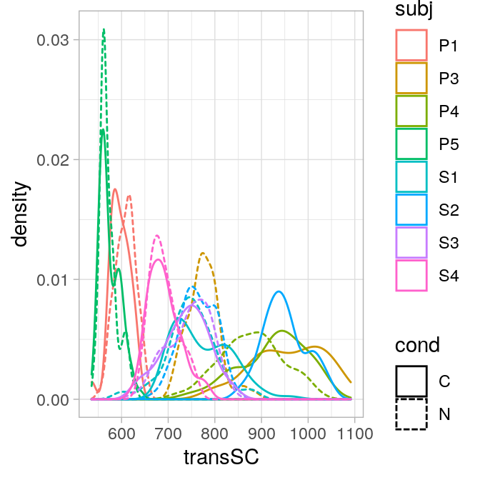

```r
ggplot(drum_beats, aes(transSC,
                       color = subj,
                       linetype = cond)) +
  geom_density(alpha = 0.1)
```

Fig. 3. *`transSC` density distribution of participants, broken down by instruction condition.*

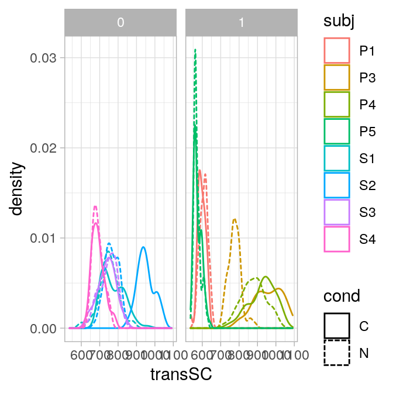

```r
ggplot(drum_beats, aes(transSC,
                       color = subj,
                       linetype = cond)) +
  geom_density(alpha = 0.1) +
  facet_wrap(~ patient)
```

Fig. 4. *`transSC` density distribution of participants, broken down by instruction condition and group (patients and healthy controls).*

# 2 Modeling

Sofia, on 2020-07-07: “The main hypothesis is that playing instruction (N/C) will affect the stroke in a way that is perceivable”.

## 2.1 Simple Univariate Models

Looking again at the variables agreed upon *I* have decided to use as response variables in the regression models—implying that this is by no means set in stone—, it seems like a skewed normal link function would be appropriate to model them.

Let’s start with `transSC``totDur`. Using an extended model description language (Bates 2010; Bürkner 2018), going back to Wilkinson and Rogers’s (1973) modeling language, we write:

```r
(m0_form <-bf(transSC ~ 1 + (1 | subj)))
```

```
transSC ~ 1 + (1 | subj)
```

which claims that `transSC` is explained by (‘~’) an intercept, denoted by ‘1’, and an additional term ‘(1 | subj)’. The ‘1’ in parentheses again stands for the intercept, but the pipe ‘|’ assigns an intercept to each level of the factor ‘subj’. In this particular case this means that the model will estimate an individual intercept for each unique drummer listed in the data set column `subj`. These individual, or varying, intercepts are then used in informing the estimation of the population intercept.

Note: set `MODEL` to `TRUE` at the top of the script if you didn’t compile/build your model yet.

```r
if (MODEL) {
  m0 <- brm(m0_form,
            family = skew_normal(),
            data = drum_beats)
  m0 <- add_criterion(m0,
                      "loo",
                      reloo = TRUE)
  save(m0,
       file = "m0.rda")
} else {
  load("m0.rda")
}
```

This null model is also termed unconditional model because it has no grouping structure apart from individuals–the ‘subj’ bit in the model equation above. There is some variation in every natural data set. To make sure, it’s not just variation caused by different participants, we can calculate the intra-class correlation coefficient (ICC).

```r
m0_icc <- ICC(m0, "subj")
```

The Null model’s ICC amounts to 0.76, which suggests that approx. 76 percent of the variation in the data set can be attributed to (or explained by) the grouping structure. This is highly unfortunate, as it does not leave a lot of variation to be explained by independent factors like instruction, or arm. The most likely reason for this high ICC value is the small sample size combined with high inter-individual variation. Small sample sizes combined with large trial numbers are less of a problem when subjects respond, on average, close to the population mean, even with large spread due to fluctuating alertness, increasing fatigue etc., *.e.g.* in reaction time paradigms. But here, with large intra- *and* inter-individual variation, this might become a problem.

Tab. 1. *Model summary.*

```r
(m0_summary <- summary(m0,
                       priors = TRUE))
```

```
 Family: skew_normal
  Links: mu = identity; sigma = identity; alpha = identity
Formula: transSC ~ 1 + (1 | subj)
   Data: drum_beats (Number of observations: 1102)
Samples: 4 chains, each with iter = 2000; warmup = 1000; thin = 1;
         total post-warmup samples = 4000

Priors:
alpha ~ normal(0, 4)
Intercept ~ student_t(3, 735, 136.5)
sd ~ student_t(3, 0, 136.5)
sigma ~ student_t(3, 0, 136.5)

Group-Level Effects:
~subj (Number of levels: 8)
              Estimate Est.Error l-95% CI u-95% CI Rhat Bulk_ESS Tail_ESS
sd(Intercept)   115.75     34.04    69.64   200.19 1.00      727      973

Population-Level Effects:
          Estimate Est.Error l-95% CI u-95% CI Rhat Bulk_ESS Tail_ESS
Intercept   749.42     41.69   668.19   836.04 1.01      572      671

Family Specific Parameters:
      Estimate Est.Error l-95% CI u-95% CI Rhat Bulk_ESS Tail_ESS
sigma    64.92      1.52    62.08    68.08 1.00     2413     2232
alpha     3.13      0.32     2.53     3.80 1.00     2033     2071

Samples were drawn using sampling(NUTS). For each parameter, Bulk_ESS
and Tail_ESS are effective sample size measures, and Rhat is the potential
scale reduction factor on split chains (at convergence, Rhat = 1).
```

The intercept in Tab. 1 amounts to roughly 749. In this model specification, the intercept is identical to the data set average. The table also shows that the inter-individual standard deviation (`sd(Intercept)`) is large compared to the unexplained variation (`sigma`). This led to the large ICC value above. By adding more and more independent factors to the model specification, we will later try to decrease $\sigma$, *i.e.* ‘explain away’ as much remaining variation as possible.

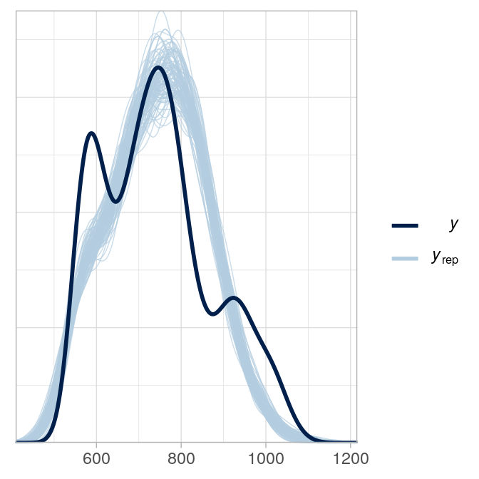

```r
pp_check(m0, nsamples = 100)
```

Fig. 5. *Posterior predictive check. The thick blue line shows the distribution of the empirical data. The thin blue lines are one-hundred realizations of data generated from parameters estimated by the model.*

The posterior predictive plot in Fig. 5 gives an impression on how the null model would generate data, given the parameters it estimated from the empirical data. As the thick line deviates from the modeled thin lines, especially on the left and the right side of the peak of the distribution, it is apparent that the model can be improved.

```r
# conditional_effects(m0)
```

### 2.1.1 Conditions Model

In this model, the intercept is complemented with second ‘main’ or population effect, the instruction condition `cond`:

```r
(m1_form <-bf(transSC ~ 1 + cond +
                (1 | subj)))
```

```
transSC ~ 1 + cond + (1 | subj)
```

I could have also specified the model without the explicit ‘1 +’, as the intercept is implicitly included in the model unless I explicitly exclude it. From now on I will always save some extra typing by refraining from explicitly indluding the intercept in models.

So now the model not only contains the individuals as grouping structure to ‘explain away’ variation, but also the manipulations.

```r
(m1_prior <- set_prior("normal(0, 10)", class = "sd"))
```

```
sd ~ normal(0, 10)
```

```r
if (MODEL) {
  m1 <- brm(m1_form,
            family = skew_normal(),
            data = drum_beats)
  m1 <- add_criterion(m1,
                      "loo",
                      reloo = TRUE)
  save(m1,
       file = "m1.rda")
} else {
  load("m1.rda")
}
```

Tab. 2. *Model summary.*

```r
(m1_summary <- summary(m1,
                       priors = TRUE))
```

```
 Family: skew_normal
  Links: mu = identity; sigma = identity; alpha = identity
Formula: transSC ~ 1 + cond + (1 | subj)
   Data: drum_beats (Number of observations: 1102)
Samples: 4 chains, each with iter = 2000; warmup = 1000; thin = 1;
         total post-warmup samples = 4000

Priors:
alpha ~ normal(0, 4)
Intercept ~ student_t(3, 735, 136.5)
sd ~ student_t(3, 0, 136.5)
sigma ~ student_t(3, 0, 136.5)

Group-Level Effects:
~subj (Number of levels: 8)
              Estimate Est.Error l-95% CI u-95% CI Rhat Bulk_ESS Tail_ESS
sd(Intercept)   127.56     37.85    75.96   222.19 1.00      673      888

Population-Level Effects:
          Estimate Est.Error l-95% CI u-95% CI Rhat Bulk_ESS Tail_ESS
Intercept   769.83     43.07   680.31   855.11 1.01      748     1184
condN       -41.88      3.76   -49.33   -34.52 1.00     2663     2215

Family Specific Parameters:
      Estimate Est.Error l-95% CI u-95% CI Rhat Bulk_ESS Tail_ESS
sigma    59.80      1.39    57.16    62.59 1.00     2534     2261
alpha     1.93      0.32     1.31     2.58 1.00     2090     2393

Samples were drawn using sampling(NUTS). For each parameter, Bulk_ESS
and Tail_ESS are effective sample size measures, and Rhat is the potential
scale reduction factor on split chains (at convergence, Rhat = 1).
```

The intercept in Tab. 2 amounts to roughly 770. In this model specification, the intercept is identical to the controlled strokes, while the `condN` value is the mean of the posterior distribution *difference* between controlled and normal strokes (-42). The table also shows that the interindividual standard deviation (`sd(Intercept)` $\approx$ 128 is still large compared to the unexplained variation (`sigma` $\approx$ 60).

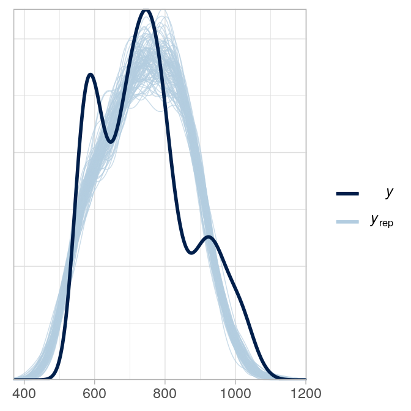

```r
pp_check(m1, nsamples = 100)
```

Fig. 6. *Posterior predictive check. The thick blue line shows the distribution of the empirical data. The thin blue lines are one-hundred realizations of data generated from parameters estimated by the model.*

The posterior predictive plot in Fig. 6 gives an impression on how this model would generate data, given the parameters it estimated from the empirical data. There is not much change from Fig. 5, which is not very surprising given the small estimated difference between the conditions.

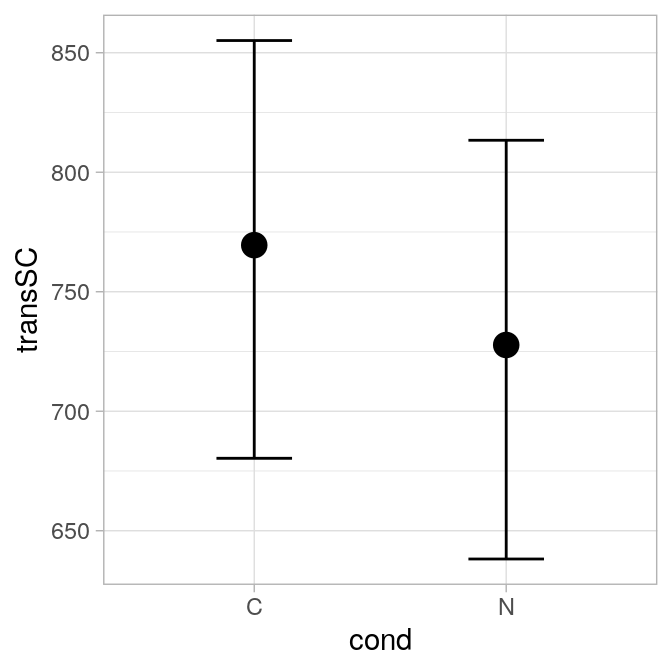

```r
conditional_effects(m1)
```

### 2.1.2 ConditionsVI Model

The last model included the instruction condition, more realistically reflecting the true structure of the data set. But it did not acknowledge that each subject executed several strokes in each of these conditions. This model includes a term with a varying intercept (VI) for condition to reflect just that, which will also assist in more realistically estimate the population effect of `cond`:

```r
(m2_form <-bf(transSC ~ cond +
                (1 | subj) +
                (1 | cond)))
```

```
transSC ~ cond + (1 | subj) + (1 | cond)
```

Including more varying parameters in the model requires the prior on them to be even stronger:

```r
(m2_prior <- set_prior("normal(0, 5)", class = "sd"))
```

```
sd ~ normal(0, 5)
```

```r
if (MODEL) {
  m2 <- brm(m2_form,
            prior = m2_prior,
            family = skew_normal(),
            data = drum_beats,
            control = list(adapt_delta = 0.95))
  m2 <- add_criterion(m2,
                      "loo",
                      reloo = TRUE)
  save(m2,
       file = "m2.rda")
} else {
  load("m2.rda")
}
```

Tab. 3. *Model summary.*

```r
(m2_summary <- summary(m2,
                       priors = TRUE))
```

```
 Family: skew_normal
  Links: mu = identity; sigma = identity; alpha = identity
Formula: transSC ~ cond + (1 | subj) + (1 | cond)
   Data: drum_beats (Number of observations: 1102)
Samples: 4 chains, each with iter = 2000; warmup = 1000; thin = 1;
         total post-warmup samples = 4000

Priors:
alpha ~ normal(0, 4)
Intercept ~ student_t(3, 735, 136.5)
sd ~ normal(0, 5)
sigma ~ student_t(3, 0, 136.5)

Group-Level Effects:
~cond (Number of levels: 2)
              Estimate Est.Error l-95% CI u-95% CI Rhat Bulk_ESS Tail_ESS
sd(Intercept)     3.93      2.97     0.11    11.07 1.00     1765     1113

~subj (Number of levels: 8)
              Estimate Est.Error l-95% CI u-95% CI Rhat Bulk_ESS Tail_ESS
sd(Intercept)    37.23      2.41    32.65    42.11 1.00     2512     2188

Population-Level Effects:
          Estimate Est.Error l-95% CI u-95% CI Rhat Bulk_ESS Tail_ESS
Intercept   768.70     14.27   740.46   796.79 1.00     1018     1537
condN       -39.68      7.60   -55.72   -23.79 1.00     2380     2097

Family Specific Parameters:
      Estimate Est.Error l-95% CI u-95% CI Rhat Bulk_ESS Tail_ESS
sigma    60.29      1.44    57.64    63.23 1.00     3353     2390
alpha     2.27      0.34     1.65     2.97 1.00     3305     2642

Samples were drawn using sampling(NUTS). For each parameter, Bulk_ESS
and Tail_ESS are effective sample size measures, and Rhat is the potential
scale reduction factor on split chains (at convergence, Rhat = 1).
```

The intercept in Tab. 3 amounts to roughly 769. In this model specification, the intercept is identical to the controlled strokes, while the `condN` value is the mean of the posterior distribution *difference* between controlled and normal strokes (-40). The table also shows that the inter-individual standard deviation (`sd(Intercept)` $\approx$ 37 is not large anymore compared to the unexplained variation (`sigma` $\approx$ 60).

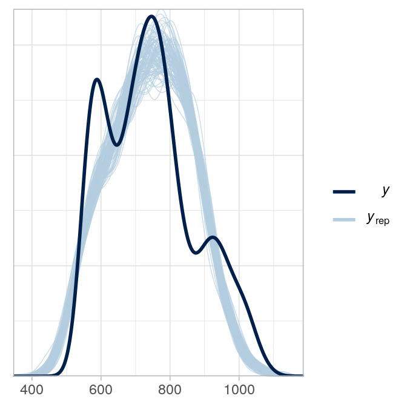

```r
pp_check(m2, nsamples = 100)
```

Fig. 7. *Posterior predictive check. The thick blue line shows the distribution of the empirical data. The thin blue lines are one-hundred realizations of data generated from parameters estimated by the model.*

The posterior predictive plot in Fig. 7 gives an impression on how this model would generate data, given the parameters it estimated from the empirical data. There is not much change from Fig. 5, which is not very surprising given the small estimated difference between the conditions.

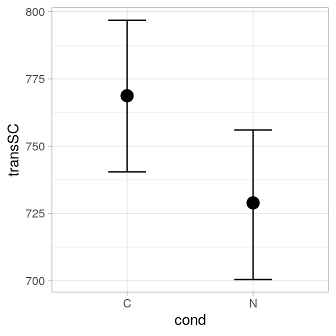

```r
conditional_effects(m2)
```

### 2.1.3 Condition + Arm Model

```r
(m3_form <-bf(transSC ~ cond + arm +
                (1 | subj) +
                (1 | cond) +
                (1 | arm)))
```

```
transSC ~ cond + arm + (1 | subj) + (1 | cond) + (1 | arm)
```

```r
(m3_prior <- c(set_prior("normal(0, 1)", class = "sd")))
```

```
sd ~ normal(0, 1)
```

```r
if (MODEL) {
  m3 <- brm(m3_form,
            prior = m3_prior,
            family = skew_normal(),
            data = drum_beats,
            control = list(adapt_delta = 0.95))
  m3 <- add_criterion(m3,
                      "loo",
                      reloo = TRUE)
  save(m3,
       file = "m3.rda")
} else {
  load("m3.rda")
}
```

Tab. 4. *Model summary.*

```r
(m3_summary <- summary(m3,
                       priors = TRUE))
```

```
 Family: skew_normal
  Links: mu = identity; sigma = identity; alpha = identity
Formula: transSC ~ cond + arm + (1 | subj) + (1 | cond) + (1 | arm)
   Data: drum_beats (Number of observations: 1102)
Samples: 4 chains, each with iter = 2000; warmup = 1000; thin = 1;
         total post-warmup samples = 4000

Priors:
alpha ~ normal(0, 4)
Intercept ~ student_t(3, 735, 136.5)
sd ~ normal(0, 1)
sigma ~ student_t(3, 0, 136.5)

Group-Level Effects:
~arm (Number of levels: 2)
              Estimate Est.Error l-95% CI u-95% CI Rhat Bulk_ESS Tail_ESS
sd(Intercept)     0.78      0.61     0.02     2.24 1.00     2041     1337

~cond (Number of levels: 2)
              Estimate Est.Error l-95% CI u-95% CI Rhat Bulk_ESS Tail_ESS
sd(Intercept)     0.79      0.61     0.03     2.24 1.00     2546     1371

~subj (Number of levels: 8)
              Estimate Est.Error l-95% CI u-95% CI Rhat Bulk_ESS Tail_ESS
sd(Intercept)    15.79      0.55    14.71    16.89 1.00     2340     2518

Population-Level Effects:
          Estimate Est.Error l-95% CI u-95% CI Rhat Bulk_ESS Tail_ESS
Intercept   764.71      6.45   751.77   777.45 1.00     1128     1544
condN       -29.53      4.01   -37.67   -21.71 1.00     2930     2994
armND        -1.79      3.68    -9.07     5.53 1.00     3355     2549

Family Specific Parameters:
      Estimate Est.Error l-95% CI u-95% CI Rhat Bulk_ESS Tail_ESS
sigma    63.53      1.64    60.46    66.74 1.00     2973     3117
alpha     3.69      0.42     2.94     4.53 1.00     2542     2991

Samples were drawn using sampling(NUTS). For each parameter, Bulk_ESS
and Tail_ESS are effective sample size measures, and Rhat is the potential
scale reduction factor on split chains (at convergence, Rhat = 1).
```

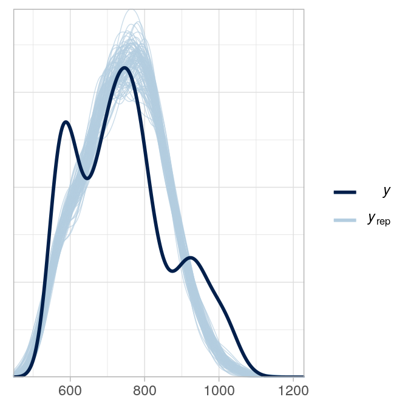

```r
pp_check(m3, nsamples = 100)
```

Fig. 8. *Posterior predictive check. The thick blue line shows the distribution of the empirical data. The thin blue lines are one-hundred realizations of data generated from parameters estimated by the model.*

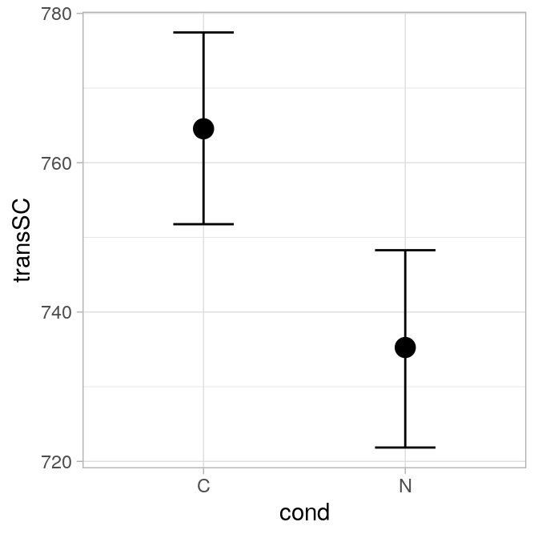

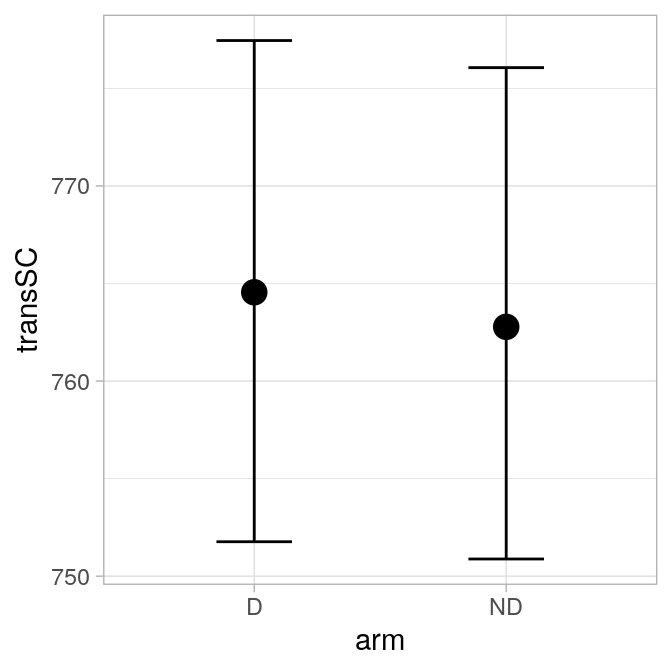

```r
conditional_effects(m3)
```

### 2.1.4 Condition x Arm Model

```r
(m4_form <-bf(transSC ~ cond * arm +
                (1 | subj) +
                (1 | cond) +
                (1 | arm)))
```

```
transSC ~ cond * arm + (1 | subj) + (1 | cond) + (1 | arm)
```

```r
(m4_prior <- m3_prior)
```

```
sd ~ normal(0, 1)
```

```r
if (MODEL) {
  m4 <- brm(m4_form,
            prior = m4_prior,
            family = skew_normal(),
            data = drum_beats,
            control = list(adapt_delta = 0.95))
  m4 <- add_criterion(m4,
                      "loo",
                      reloo = TRUE)
  save(m4,
       file = "m4.rda")
} else {
  load("m4.rda")
}
```

Tab. 5. *Model summary.*

```r
(m4_summary <- summary(m4,
                       priors = TRUE))
```

```
 Family: skew_normal
  Links: mu = identity; sigma = identity; alpha = identity
Formula: transSC ~ cond * arm + (1 | subj) + (1 | cond) + (1 | arm)
   Data: drum_beats (Number of observations: 1102)
Samples: 4 chains, each with iter = 2000; warmup = 1000; thin = 1;
         total post-warmup samples = 4000

Priors:
alpha ~ normal(0, 4)
Intercept ~ student_t(3, 735, 136.5)
sd ~ normal(0, 1)
sigma ~ student_t(3, 0, 136.5)

Group-Level Effects:
~arm (Number of levels: 2)
              Estimate Est.Error l-95% CI u-95% CI Rhat Bulk_ESS Tail_ESS
sd(Intercept)     0.81      0.60     0.03     2.26 1.00     2845     1733

~cond (Number of levels: 2)
              Estimate Est.Error l-95% CI u-95% CI Rhat Bulk_ESS Tail_ESS
sd(Intercept)     0.81      0.60     0.03     2.23 1.00     2913     1752

~subj (Number of levels: 8)
              Estimate Est.Error l-95% CI u-95% CI Rhat Bulk_ESS Tail_ESS
sd(Intercept)    15.80      0.55    14.75    16.91 1.00     2912     2831

Population-Level Effects:
            Estimate Est.Error l-95% CI u-95% CI Rhat Bulk_ESS Tail_ESS
Intercept     765.11      6.77   752.04   778.01 1.00     1360     2134
condN         -31.45      5.16   -41.61   -21.47 1.00     2870     2947
armND          -3.77      4.78   -12.76     5.62 1.00     2575     2930
condN:armND     3.98      6.67    -9.02    16.86 1.00     2648     2945

Family Specific Parameters:
      Estimate Est.Error l-95% CI u-95% CI Rhat Bulk_ESS Tail_ESS
sigma    63.69      1.65    60.60    67.09 1.00     2847     2839
alpha     3.76      0.45     2.92     4.68 1.00     2695     2549

Samples were drawn using sampling(NUTS). For each parameter, Bulk_ESS
and Tail_ESS are effective sample size measures, and Rhat is the potential
scale reduction factor on split chains (at convergence, Rhat = 1).
```

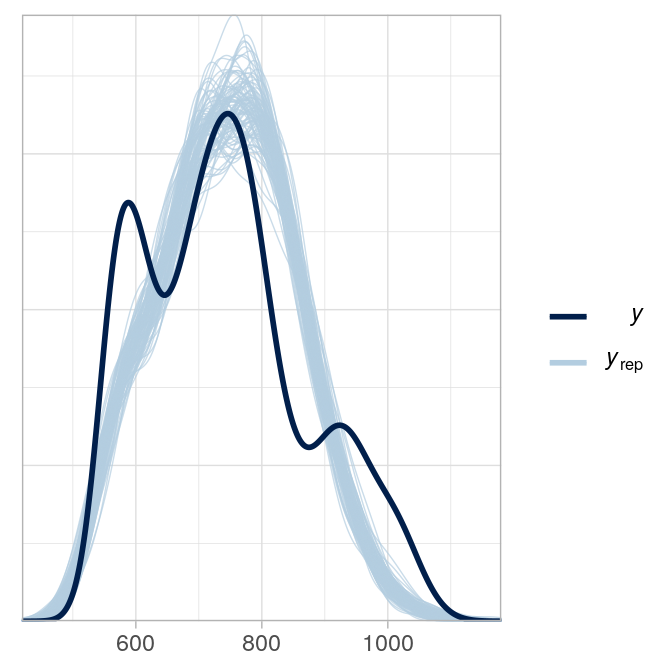

```r
pp_check(m4, nsamples = 100)
```

Fig. 9. *Posterior predictive check. The thick blue line shows the distribution of the empirical data. The thin blue lines are one-hundred realizations of data generated from parameters estimated by the model.*

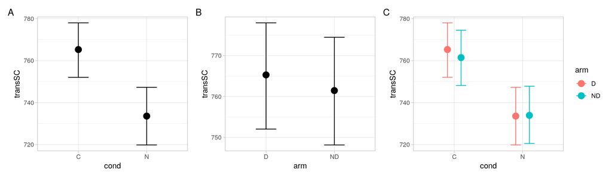

```r
wrap_plots(plot(conditional_effects(m4),
             plot = FALSE)) +
  plot_annotation(tag_levels = "A")
```

### 2.1.5 Modeling Condition-specific Variation

As is apparent from Fig. 1, the controlled condition yielded broader density distributions in most descriptors. Hence, we model condition-dependent variation in the next model:

```r
(m5_form <-bf(transSC ~ cond * arm +
                (1 | subj) +
                (1 | cond) +
                (1 | arm),
              sigma ~ cond))
```

```
transSC ~ cond * arm + (1 | subj) + (1 | cond) + (1 | arm)
sigma ~ cond
```

This model has now two outcomes, not just one, as the models before. Spread is estimated as `sigma`, and it varies conditional on instruction condition.

Here’s the non-standard (additional) prior:

```r
(m5_prior <- m4_prior)
```

```
sd ~ normal(0, 1)
```

```r
if (MODEL) {
  m5 <- brm(m5_form,
            prior = m5_prior,
            family = skew_normal(),
            data = drum_beats,
            control = list(adapt_delta = 0.95))
  m5 <- add_criterion(m5,
                      "loo",
                      reloo = TRUE)
  save(m5,
       file = "m5.rda")
} else {
  load("m5.rda")
}
```

Tab. 6. *Model summary.*

```r
(m5_summary <- summary(m5,
                       priors = TRUE))
```

```
 Family: skew_normal
  Links: mu = identity; sigma = log; alpha = identity
Formula: transSC ~ cond * arm + (1 | subj) + (1 | cond) + (1 | arm)
         sigma ~ cond
   Data: drum_beats (Number of observations: 1102)
Samples: 4 chains, each with iter = 2000; warmup = 1000; thin = 1;
         total post-warmup samples = 4000

Priors:
alpha ~ normal(0, 4)
Intercept ~ student_t(3, 735, 136.5)
Intercept_sigma ~ student_t(3, 0, 2.5)
sd ~ normal(0, 1)

Group-Level Effects:
~arm (Number of levels: 2)
              Estimate Est.Error l-95% CI u-95% CI Rhat Bulk_ESS Tail_ESS
sd(Intercept)     0.80      0.60     0.04     2.23 1.00     2949     1635

~cond (Number of levels: 2)
              Estimate Est.Error l-95% CI u-95% CI Rhat Bulk_ESS Tail_ESS
sd(Intercept)     0.79      0.61     0.04     2.24 1.00     3664     2018

~subj (Number of levels: 8)
              Estimate Est.Error l-95% CI u-95% CI Rhat Bulk_ESS Tail_ESS
sd(Intercept)    15.27      0.55    14.23    16.34 1.00     3358     2897

Population-Level Effects:
                Estimate Est.Error l-95% CI u-95% CI Rhat Bulk_ESS Tail_ESS
Intercept         770.69      7.06   756.94   784.79 1.00     1396     2107
sigma_Intercept     4.37      0.04     4.30     4.44 1.00     4245     2810
condN             -44.19      5.37   -54.85   -33.71 1.00     3025     2756
armND              -3.06      5.99   -14.80     9.01 1.00     2303     3077
condN:armND         0.74      6.92   -12.73    14.48 1.00     2433     2717
sigma_condN        -0.51      0.05    -0.61    -0.41 1.00     4667     3130

Family Specific Parameters:
      Estimate Est.Error l-95% CI u-95% CI Rhat Bulk_ESS Tail_ESS
alpha     3.24      0.38     2.55     4.01 1.00     3031     2876

Samples were drawn using sampling(NUTS). For each parameter, Bulk_ESS
and Tail_ESS are effective sample size measures, and Rhat is the potential
scale reduction factor on split chains (at convergence, Rhat = 1).
```

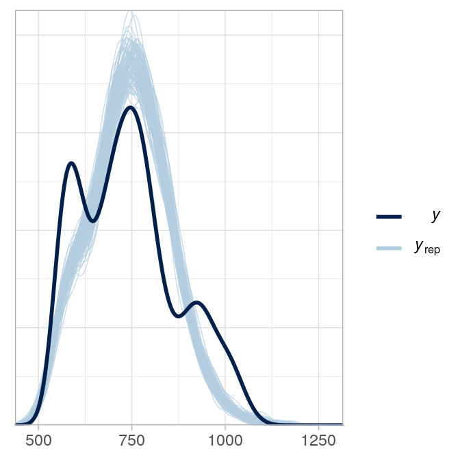

```r
pp_check(m5, nsamples = 100)
```

Fig. 10. *Posterior predictive check. The thick blue line shows the distribution of the empirical data. The thin blue lines are one-hundred realizations of data generated from parameters estimated by the model.*

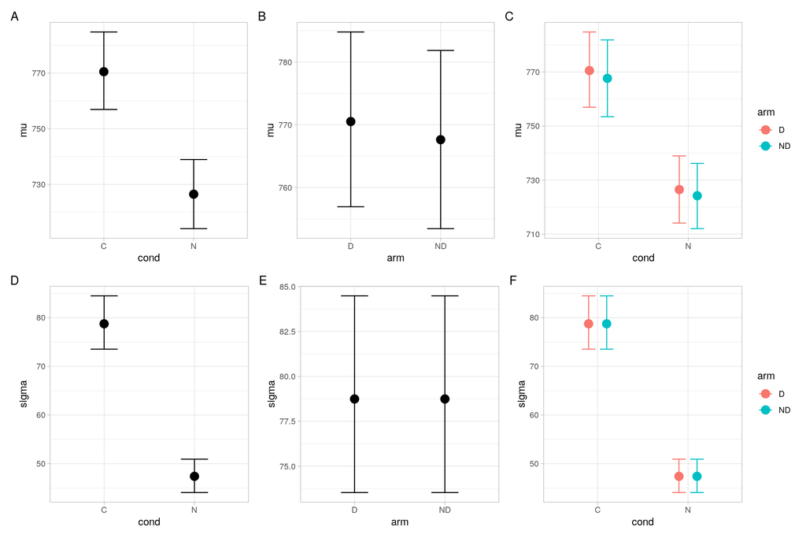

```r
p <- plot(conditional_effects(m5,
                              dpar = "mu"),
          plot = FALSE)
p1 <- wrap_plots(p[[1]]+
                   p[[2]] +
                   p[[3]])
p <- plot(conditional_effects(m5,
                              dpar = "sigma"),
          plot = FALSE)
p2 <- wrap_plots(p[[1]]+
                   p[[2]] +
                   p[[3]])
wrap_plots(p1, p2,
           ncol = 1) +
  plot_annotation(tag_levels = "A")
```

Fig. 11. *Conditional plot.*

In Fig. 11 we see a difference between the mean (‘mu’) estimated value for `transSC` depending on instruction condition (A), but no difference between dominant and non-dominant arm (B). Consequently, there is no interaction in (C).

The spread (`sigma`) of the estimated distributions also differs between conditions (D), but again not between arms (E). The latter is not surprising because we modeled sigma to vary conditional on condition, not arm.

### 2.1.6 Modeling Arm-specific Skewness

At least in some descriptors in Fig. 1 the skewness of the distribution seems to change depending on the arm. The skew normal distribution is a generalization of the Gaussian distribution, allowing for the additional shape-parameter skewness (asymmetry) to vary. Hence, we model this side-dependent skewness in the next model:

```r
(m6_form <-bf(transSC ~ cond * arm +
                (1 | subj) +
                (1 | cond) +
                (1 | arm),
              sigma ~ cond,
              alpha ~ arm))
```

```
transSC ~ cond * arm + (1 | subj) + (1 | cond) + (1 | arm)
sigma ~ cond
alpha ~ arm
```

```r
(m6_prior <- m5_prior)
```

```
sd ~ normal(0, 1)
```

```r
if (MODEL) {
  m6 <- brm(m6_form,
            prior = m6_prior,
            family = skew_normal(),
            data = drum_beats,
            control = list(adapt_delta = 0.95))
  m6 <- add_criterion(m6,
                      "loo",
                      reloo = TRUE)
  save(m6,
       file = "m6.rda")
} else {
  load("m6.rda")
}
```

Tab. 7. *Model summary.*

```r
(m6_summary <- summary(m6,
                       priors = TRUE))
```

```
 Family: skew_normal
  Links: mu = identity; sigma = log; alpha = identity
Formula: transSC ~ cond * arm + (1 | subj) + (1 | cond) + (1 | arm)
         sigma ~ cond
         alpha ~ arm
   Data: drum_beats (Number of observations: 1102)
Samples: 4 chains, each with iter = 2000; warmup = 1000; thin = 1;
         total post-warmup samples = 4000

Priors:
Intercept ~ student_t(3, 735, 136.5)
Intercept_alpha ~ normal(0, 4)
Intercept_sigma ~ student_t(3, 0, 2.5)
sd ~ normal(0, 1)

Group-Level Effects:
~arm (Number of levels: 2)
              Estimate Est.Error l-95% CI u-95% CI Rhat Bulk_ESS Tail_ESS
sd(Intercept)     0.79      0.59     0.03     2.19 1.00     3130     1788

~cond (Number of levels: 2)
              Estimate Est.Error l-95% CI u-95% CI Rhat Bulk_ESS Tail_ESS
sd(Intercept)     0.82      0.60     0.03     2.24 1.00     3027     1567

~subj (Number of levels: 8)
              Estimate Est.Error l-95% CI u-95% CI Rhat Bulk_ESS Tail_ESS
sd(Intercept)    15.17      0.53    14.16    16.21 1.00     3131     2793

Population-Level Effects:
                Estimate Est.Error l-95% CI u-95% CI Rhat Bulk_ESS Tail_ESS
Intercept         768.39      7.12   754.82   783.22 1.00     1441     2184
sigma_Intercept     4.39      0.03     4.32     4.46 1.00     4424     3168
alpha_Intercept     2.53      0.39     1.81     3.36 1.00     4053     2988
condN             -41.50      5.60   -52.58   -30.41 1.00     2703     2997
armND              -0.73      6.11   -12.59    11.37 1.00     2379     3015
condN:armND        -2.39      6.91   -16.22    11.14 1.00     2214     2619
sigma_condN        -0.54      0.05    -0.64    -0.45 1.00     4218     2900
alpha_armND         2.14      0.67     0.84     3.48 1.00     3844     2780

Samples were drawn using sampling(NUTS). For each parameter, Bulk_ESS
and Tail_ESS are effective sample size measures, and Rhat is the potential
scale reduction factor on split chains (at convergence, Rhat = 1).
```

In the Population-Level Effects section of Tab. 7 are now two estimates for the skewness parameter alpha (one for the dominant [`alpha_Intercept`] and one for the non-dominant arm [`alpha_armND`]), while there is no entry for alpha in the Family Specific section anymore. All this due to our explicit modeling of alpha conditional on arm.

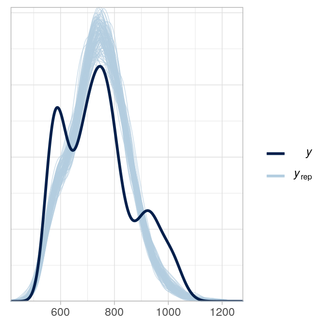

```r
pp_check(m6, nsamples = 100)
```

Fig. 12. *Posterior predictive check. The thick blue line shows the distribution of the empirical data. The thin blue lines are one-hundred realizations of data generated from parameters estimated by the model.*

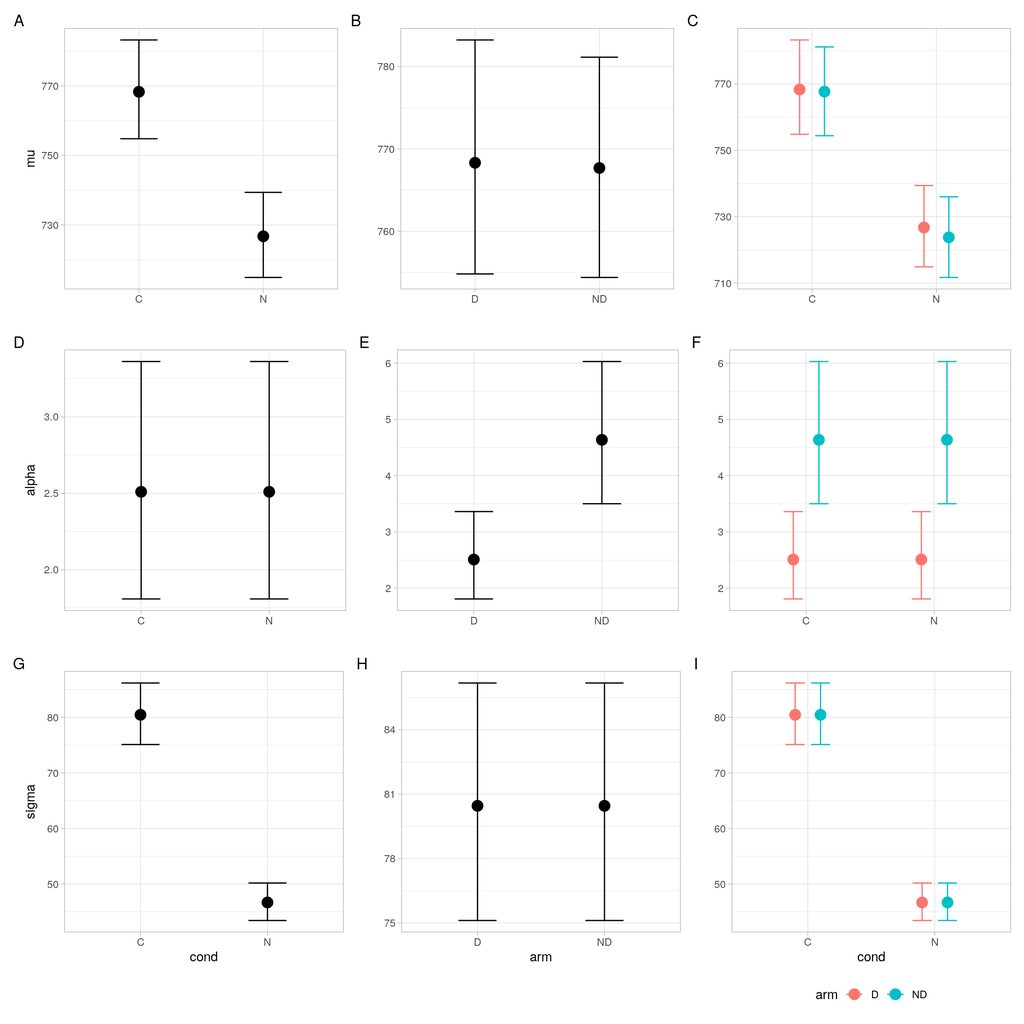

```r
p <- plot(conditional_effects(m6,
                              dpar = "mu"),
          plot = FALSE)
p1 <- wrap_plots(p[[1]] + xlab("") +
                   p[[2]] + xlab("") + ylab("") +
                   p[[3]] + xlab("") + ylab("") + theme(legend.position = "none"))
p <- plot(conditional_effects(m6,
                              dpar = "alpha"),
          plot = FALSE)
p2 <- wrap_plots(p[[1]] + xlab("") +
                   p[[2]] + xlab("") + ylab("") +
                   p[[3]] + xlab("") + ylab("") + theme(legend.position = "none"))
p <- plot(conditional_effects(m6,
                              dpar = "sigma"),
          plot = FALSE)
p3 <- wrap_plots(p[[1]] +
                   p[[2]] + ylab("") +
                   p[[3]] + ylab("") + theme(legend.position = "bottom"))
wrap_plots(p1, p2, p3,
           ncol = 1) +
  plot_annotation(tag_levels = "A")
```

Fig. 13. *Conditional plots.*

In Fig. 13 there is a clear difference in estimated mean (‘mu’) of $transSC$ conditional on instruction (A), but not on arm (B). Consequently, there is no interaction between instruction and arm (C). On the other hand, there is a difference in estimated skewness (‘alpha’) between sides (E), but not instructions (D). (F) follows from that. ‘sigma’ shows a clear difference between instructions (G), not so for side (H), which is mirrored in (I).

### 2.1.7 Modeling Influence of Instruction and Arm on Shape

To be able to see whether skewness and spread are depending on both experimental manipulation and arm, the model formulas for ‘sigma’ and ‘alpha’ are updated accordingly:

```r
(m7_form <-bf(transSC ~ cond * arm +
                (1 | subj) +
                (1 | cond) +
                (1 | arm),
              sigma ~ cond + arm,
              alpha ~ arm + cond))
```

```
transSC ~ cond * arm + (1 | subj) + (1 | cond) + (1 | arm)
sigma ~ cond + arm
alpha ~ arm + cond
```

```r
(m7_prior <- m5_prior)
```

```
sd ~ normal(0, 1)
```

```r
if (MODEL) {
  m7 <- brm(m7_form,
            prior = m7_prior,
            family = skew_normal(),
            data = drum_beats,
            control = list(adapt_delta = 0.95))
  m7 <- add_criterion(m7,
                      "loo",
                      reloo = TRUE)
  save(m7,
       file = "m7.rda")
} else {
  load("m7.rda")
}
```

Tab. 8. *Model summary.*

```r
(m7_summary <- summary(m7,
                       priors = TRUE))
```

```
 Family: skew_normal
  Links: mu = identity; sigma = log; alpha = identity
Formula: transSC ~ cond * arm + (1 | subj) + (1 | cond) + (1 | arm)
         sigma ~ cond + arm
         alpha ~ arm + cond
   Data: drum_beats (Number of observations: 1102)
Samples: 4 chains, each with iter = 2000; warmup = 1000; thin = 1;
         total post-warmup samples = 4000

Priors:
Intercept ~ student_t(3, 735, 136.5)
Intercept_alpha ~ normal(0, 4)
Intercept_sigma ~ student_t(3, 0, 2.5)
sd ~ normal(0, 1)

Group-Level Effects:
~arm (Number of levels: 2)
              Estimate Est.Error l-95% CI u-95% CI Rhat Bulk_ESS Tail_ESS
sd(Intercept)     0.78      0.61     0.02     2.25 1.00     2922     1814

~cond (Number of levels: 2)
              Estimate Est.Error l-95% CI u-95% CI Rhat Bulk_ESS Tail_ESS
sd(Intercept)     0.81      0.60     0.04     2.26 1.00     3677     1956

~subj (Number of levels: 8)
              Estimate Est.Error l-95% CI u-95% CI Rhat Bulk_ESS Tail_ESS
sd(Intercept)    15.19      0.53    14.16    16.26 1.00     3572     2999

Population-Level Effects:
                Estimate Est.Error l-95% CI u-95% CI Rhat Bulk_ESS Tail_ESS
Intercept         773.45      7.13   759.67   788.26 1.00     1438     1984
sigma_Intercept     4.36      0.04     4.28     4.45 1.00     3844     2861
alpha_Intercept     5.91      0.85     4.44     7.82 1.00     3727     2474
condN             -47.65      5.22   -58.31   -37.59 1.00     2981     3052
armND              -0.49      5.98   -11.97    11.16 1.00     2900     2775
condN:armND        -1.52      6.37   -14.11    10.96 1.00     2895     2897
sigma_condN        -0.65      0.05    -0.75    -0.55 1.00     4745     2669
sigma_armND         0.11      0.05     0.01     0.21 1.00     4121     3069
alpha_armND         2.75      0.81     1.34     4.46 1.00     3853     2905
alpha_condN        -5.49      0.96    -7.57    -3.79 1.00     3143     2711

Samples were drawn using sampling(NUTS). For each parameter, Bulk_ESS
and Tail_ESS are effective sample size measures, and Rhat is the potential
scale reduction factor on split chains (at convergence, Rhat = 1).
```

In the Population-Level Effects section of Tab. 8 are now three estimates for the skewness parameter alpha, as well as three estimates for spread (‘sigma’).

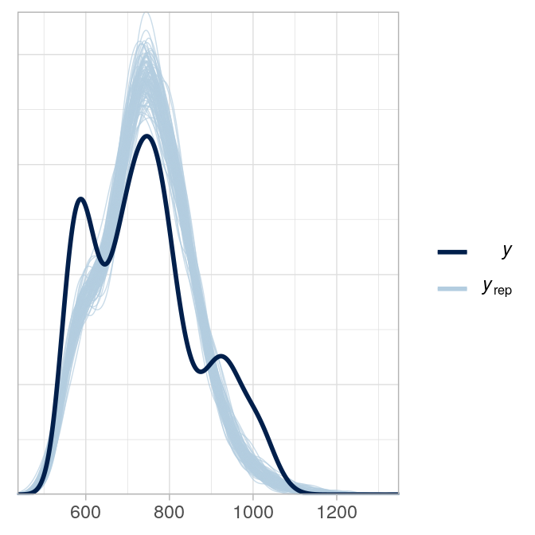

```r
pp_check(m7, nsamples = 100)
```

Fig. 14. *Posterior predictive check. The thick blue line shows the distribution of the empirical data. The thin blue lines are one-hundred realizations of data generated from parameters estimated by the model.*

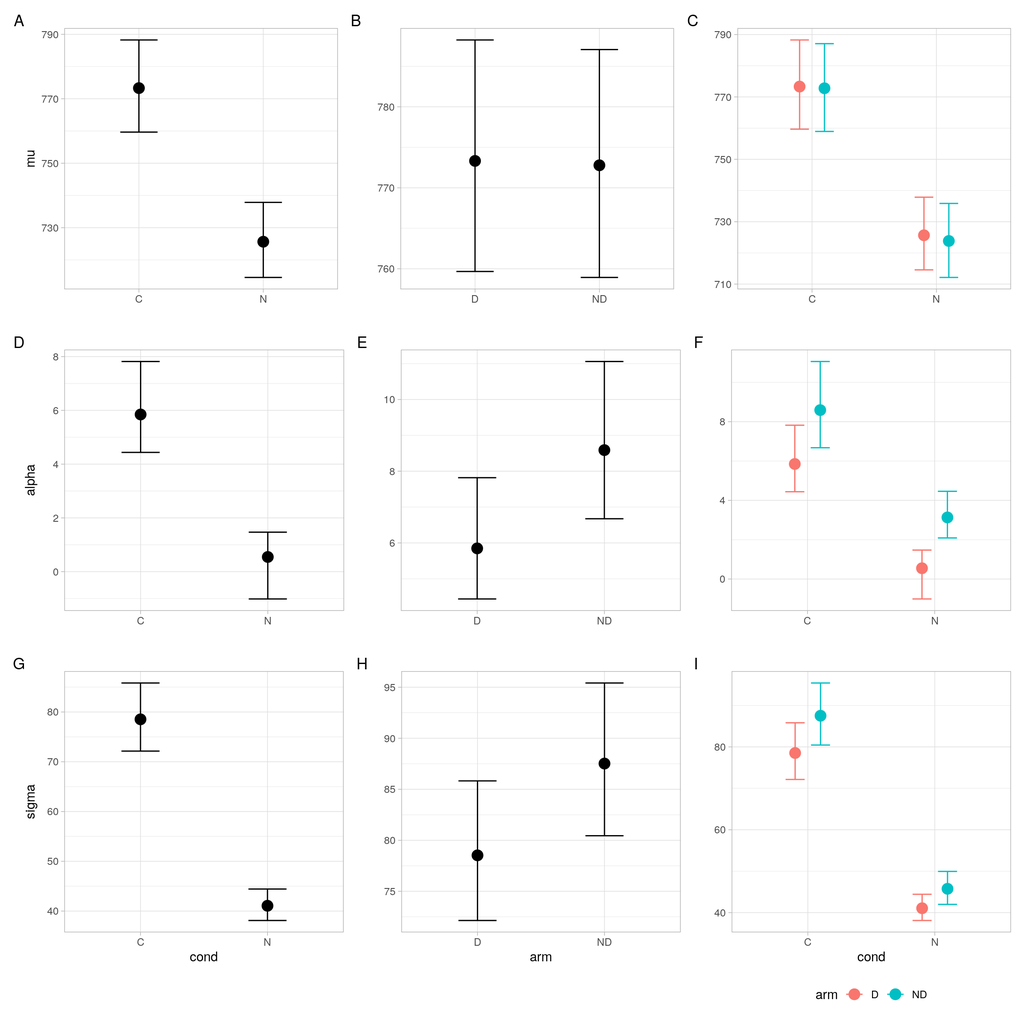

```r
p <- plot(conditional_effects(m7,
                              dpar = "mu"),
          plot = FALSE)
p1 <- wrap_plots(p[[1]] + xlab("") +
                   p[[2]] + xlab("") + ylab("") +
                   p[[3]] + xlab("") + ylab("") + theme(legend.position = "none"))
p <- plot(conditional_effects(m7,
                              dpar = "alpha"),
          plot = FALSE)
p2 <- wrap_plots(p[[1]] + xlab("") +
                   p[[2]] + xlab("") + ylab("") +
                   p[[3]] + xlab("") + ylab("") + theme(legend.position = "none"))
p <- plot(conditional_effects(m7,
                              dpar = "sigma"),
          plot = FALSE)
p3 <- wrap_plots(p[[1]] +
                   p[[2]] + ylab("") +
                   p[[3]] + ylab("") + theme(legend.position = "bottom"))
wrap_plots(p1, p2, p3,
           ncol = 1) +
  plot_annotation(tag_levels = "A")
```

Fig. 15. *Conditional plots.*

In Fig. 15 there is a clear difference in estimated mean (‘mu’) of $transSC$ conditional on instruction (A), but not on arm (B). Consequently, there is no interaction between instruction and arm (C). There is a difference in estimated skewness (‘alpha’) both between instructions (D) and sides (E), but with opposing trends. Nevertheless, there is no interaction between them (F). ‘sigma’ shows a clear difference between instructions (G) as well as for side (H), but albeit their opposing trends, there is no interaction (I).

### 2.1.8 Model Comparison

```r
loo_compare(m0, m1, m2, m3, m4, m5, m6, m7)
```

```
   elpd_diff se_diff
m7   0.0       0.0
m6 -36.7       9.3
m5 -39.2      10.4
m1 -41.0      16.8
m2 -41.8      15.5
m3 -64.5      12.6
m4 -66.2      12.6
m0 -99.0      16.2
```

### 2.1.9 Conclusion

Each row of the plot in Fig. 15 represents the results of one of the three outcomes, each column shows the estimates for one condition/manipulation. The dots in these plots are the means of the posterior distributions of the respective estimate, and can be interpreted similarly to the point estimates in traditional frequentist statistics. The error bars represent 95% credible intervals, which are interpreted as comprising the true value with 95% probability, given the model and the data.

From the first row of Fig. 15 we can infer that instructions had an effect on the mean, while arm had not. The second row suggests that instruction had a larger, and opposing, effect on skewness compared to arm arm, and finally, the third row claims the same for spread.

On a different level of understanding these results this means that `transSC` is lower in the normal strokes, with almost no skewness (alpha is close to zero) and lower spread than in controlled strokes.

Based on the above we can infer that instruction causes the most pronounced differences in `transSC`, while the playing arm only seems to invoke minor to no differences.

## 2.2 Adding the Response `transFlat`

In the following, the descriptor `transFlat` is added as an outcome to our model. Technically speaking, we would need to re-start our modeling attempt with the Null model and work our way up to the ‘best’ model as we have done with `transSC`. This is necessary because we cannot just assume that with an additional outcome (which will actually become three additional outcomes: mu, alpha and sigma) will be best explained by the same model as was with just one outcome variable.

But we take a short cut here and just add `transFlat` to the best model of `transSC`.

To be able to see whether skewness and spread are depending on both experimental manipulation and arm, the model formulas for ‘sigma’ and ‘alpha’ are updated accordingly:

```r
(m8_form <-bf(mvbind(transSC, transFlat) ~ cond + arm +
                (1|p|cond) +
                (1|q|arm) +
                (1|r|subj),
              sigma ~ cond + arm,
              alpha ~ arm + cond))
```

```
transSC ~ cond + arm + (1 | p | cond) + (1 | q | arm) + (1 | r | subj)
sigma ~ cond + arm
alpha ~ arm + cond
transFlat ~ cond + arm + (1 | p | cond) + (1 | q | arm) + (1 | r | subj)
sigma ~ cond + arm
alpha ~ arm + cond
```

The prior probability on the individual intercepts needs to reflect that there are now two response variables:

```r
#                       prior     class      coef group      resp  dpar nlpar bound
# 1                                   b
# 2                    lkj(1)       cor
# 3                                 cor             arm
# 4                                 cor            cond
# 5                                 cor            subj
# 6                           Intercept
# 7                                   b                 transFlat
# 8                                   b     armND       transFlat
# 9                                   b     condN       transFlat
# 10   student_t(3, 0.8, 2.5) Intercept                 transFlat
# 11     student_t(3, 0, 2.5)        sd                 transFlat
# 12                                 sd             arm transFlat
# 13                                 sd Intercept   arm transFlat
# 14                                 sd            cond transFlat
# 15                                 sd Intercept  cond transFlat
# 16                                 sd            subj transFlat
# 17                                 sd Intercept  subj transFlat
# 18                                  b                 transFlat alpha
# 19                                  b     armND       transFlat alpha
# 20                                  b     condN       transFlat alpha
# 21             normal(0, 4) Intercept                 transFlat alpha
# 22                                  b                 transFlat sigma
# 23                                  b     armND       transFlat sigma
# 24                                  b     condN       transFlat sigma
# 25     student_t(3, 0, 2.5) Intercept                 transFlat sigma
# 26                                  b                   transSC
# 27                                  b     armND         transSC
# 28                                  b     condN         transSC
# 29 student_t(3, 735, 136.5) Intercept                   transSC
# 30   student_t(3, 0, 136.5)        sd                   transSC
# 31                                 sd             arm   transSC
# 32                                 sd Intercept   arm   transSC
# 33                                 sd            cond   transSC
# 34                                 sd Intercept  cond   transSC
# 35                                 sd            subj   transSC
# 36                                 sd Intercept  subj   transSC
# 37                                  b                   transSC alpha
# 38                                  b     armND         transSC alpha
# 39                                  b     condN         transSC alpha
# 40             normal(0, 4) Intercept                   transSC alpha
# 41                                  b                   transSC sigma
# 42                                  b     armND         transSC sigma
# 43                                  b     condN         transSC sigma
# 44     student_t(3, 0, 2.5) Intercept                   transSC sigma
(m8_prior <- c(
  set_prior("normal(0.8, 0.01)", class = "Intercept", resp = "transFlat"),
  set_prior("normal(0, 0.01)",   class = "b",         resp = "transFlat"),
  set_prior("normal(0.8, 1)",   class = "Intercept", resp = "transSC"),
  set_prior("normal(0, 1)",     class = "b",         resp = "transSC"),
  set_prior("normal(0, 0.01)",   class = "Intercept", resp = "transFlat", dpar = "alpha"),
  set_prior("normal(0, 0.01)",   class = "b",         resp = "transFlat", dpar = "alpha"),
  set_prior("normal(0, 0.1)",   class = "Intercept", resp = "transSC",   dpar = "alpha"),
  set_prior("normal(0, 0.1)",   class = "b",         resp = "transSC",   dpar = "alpha"),
  set_prior("normal(0, 0.05)",   class = "Intercept", resp = "transSC",   dpar = "sigma"),
  set_prior("normal(0, 0.05)",   class = "b",         resp = "transSC",   dpar = "sigma"),
  set_prior("normal(0, 0.01)",   class = "Intercept", resp = "transFlat", dpar = "sigma"),
  set_prior("normal(0, 0.01)",   class = "b",         resp = "transFlat", dpar = "sigma"),
  set_prior("normal(0, 0.05)",   class = "sd",        resp = "transSC"),
  set_prior("normal(0, 0.01)",  class = "sd",        resp = "transFlat"),
  set_prior("lkj(5)",           class = "cor")))
```

```
               prior     class coef group      resp  dpar nlpar bound
1  normal(0.8, 0.01) Intercept            transFlat
2    normal(0, 0.01)         b            transFlat
3     normal(0.8, 1) Intercept              transSC
4       normal(0, 1)         b              transSC
5    normal(0, 0.01) Intercept            transFlat alpha
6    normal(0, 0.01)         b            transFlat alpha
7     normal(0, 0.1) Intercept              transSC alpha
8     normal(0, 0.1)         b              transSC alpha
9    normal(0, 0.05) Intercept              transSC sigma
10   normal(0, 0.05)         b              transSC sigma
11   normal(0, 0.01) Intercept            transFlat sigma
12   normal(0, 0.01)         b            transFlat sigma
13   normal(0, 0.05)        sd              transSC
14   normal(0, 0.01)        sd            transFlat
15            lkj(5)       cor
```

```r
if (MODEL) {
  t <- Sys.time()
  m8 <- brm(m8_form,
            prior = m8_prior,
            family = skew_normal(),
            data = drum_beats,
            inits = "0")
  print(Sys.time() - t)
  m8 <- add_criterion(m8,
                      "loo",
                      reloo = TRUE)
  save(m8,
       file = "m8.rda")
} else {
  load("m8.rda")
}
```

Tab. 9. *Model summary.*

```r
(m8_summary <- summary(m8,
                       priors = TRUE))
```

```
 Family: MV(skew_normal, skew_normal)
  Links: mu = identity; sigma = log; alpha = identity
         mu = identity; sigma = log; alpha = identity
Formula: transSC ~ cond + arm + (1 | p | cond) + (1 | q | arm) + (1 | r | subj)
         sigma ~ cond + arm
         alpha ~ arm + cond
         transFlat ~ cond + arm + (1 | p | cond) + (1 | q | arm) + (1 | r | subj)
         sigma ~ cond + arm
         alpha ~ arm + cond
   Data: drum_beats (Number of observations: 1102)
Samples: 4 chains, each with iter = 2000; warmup = 1000; thin = 1;
         total post-warmup samples = 4000

Priors:
b_transFlat ~ normal(0, 0.01)
b_transFlat_alpha ~ normal(0, 0.01)
b_transFlat_sigma ~ normal(0, 0.01)
b_transSC ~ normal(0, 1)
b_transSC_alpha ~ normal(0, 0.1)
b_transSC_sigma ~ normal(0, 0.05)
Intercept_transFlat ~ normal(0.8, 0.01)
Intercept_transFlat_alpha ~ normal(0, 0.01)
Intercept_transFlat_sigma ~ normal(0, 0.01)
Intercept_transSC ~ normal(0.8, 1)
Intercept_transSC_alpha ~ normal(0, 0.1)
Intercept_transSC_sigma ~ normal(0, 0.05)
L ~ lkj_corr_cholesky(5)
sd_transFlat ~ normal(0, 0.01)
sd_transSC ~ normal(0, 0.05)

Group-Level Effects:
~arm (Number of levels: 2)
                                           Estimate Est.Error l-95% CI u-95% CI
sd(transSC_Intercept)                          0.04      0.03     0.00     0.11
sd(transFlat_Intercept)                        0.01      0.01     0.00     0.02
cor(transSC_Intercept,transFlat_Intercept)    -0.00      0.30    -0.57     0.58
                                           Rhat Bulk_ESS Tail_ESS
sd(transSC_Intercept)                      1.00     3783     2503
sd(transFlat_Intercept)                    1.00     3002     1748
cor(transSC_Intercept,transFlat_Intercept) 1.00     9088     2369
```

[output cut: 49 more lines]

```
transSC_armND                 3357
sigma_transSC_condN           2763
sigma_transSC_armND           2658
alpha_transSC_armND           2978
alpha_transSC_condN           2771
transFlat_condN               2631
transFlat_armND               3278
sigma_transFlat_condN         2877
sigma_transFlat_armND         3155
alpha_transFlat_armND         2914
alpha_transFlat_condN         2831

Samples were drawn using sampling(NUTS). For each parameter, Bulk_ESS
and Tail_ESS are effective sample size measures, and Rhat is the potential
scale reduction factor on split chains (at convergence, Rhat = 1).
```

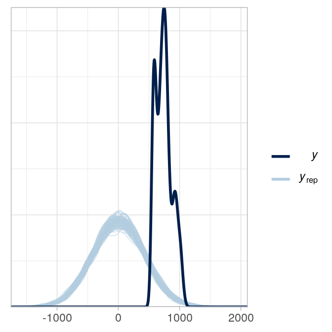

```r
pp_check(m8, resp = "transSC", nsamples = 100)
```

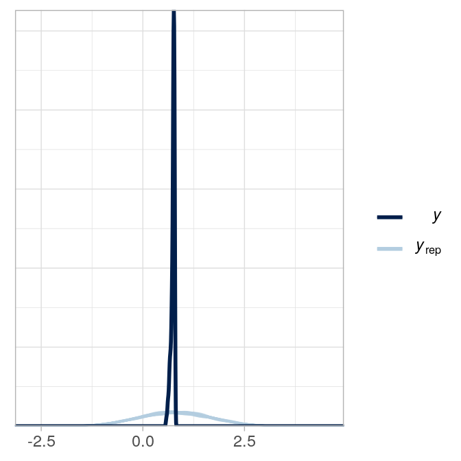

```r
pp_check(m8, resp = "transFlat", nsamples = 100)
```

Fig. 16. *Posterior predictive check. The thick blue line shows the distribution of the empirical data. The thin blue lines are one-hundred realizations of data generated from parameters estimated by the model.*

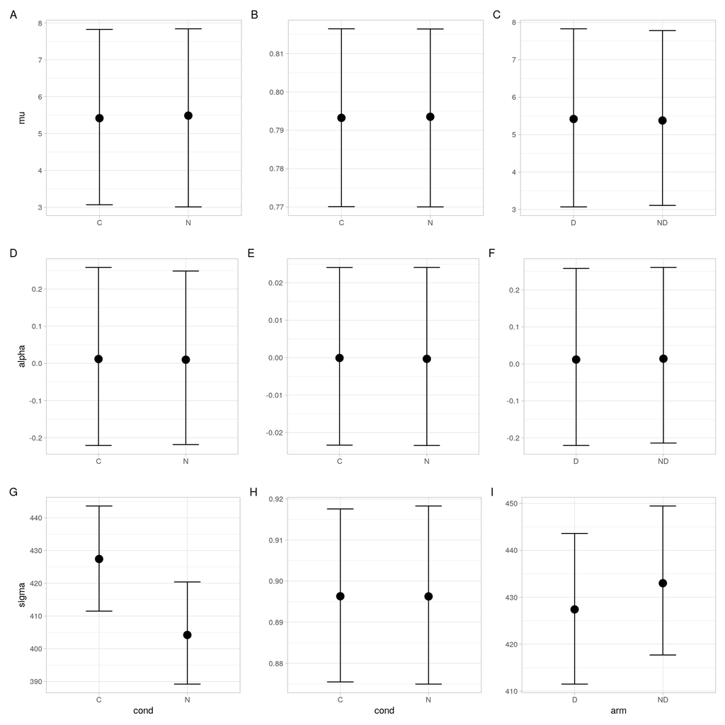

```r
p <- plot(conditional_effects(m8,
                              dpar = "mu"),
          plot = FALSE)
p1 <- wrap_plots(p[[1]] + xlab("") +
                   p[[2]] + xlab("") + ylab("") +
                   p[[3]] + xlab("") + ylab("") + theme(legend.position = "none"))
p <- plot(conditional_effects(m8,
                              dpar = "alpha"),
          plot = FALSE)
p2 <- wrap_plots(p[[1]] + xlab("") +
                   p[[2]] + xlab("") + ylab("") +
                   p[[3]] + xlab("") + ylab("") + theme(legend.position = "none"))
p <- plot(conditional_effects(m8,
                              dpar = "sigma"),
          plot = FALSE)
p3 <- wrap_plots(p[[1]] +
                   p[[2]] + ylab("") +
                   p[[3]] + ylab("") + theme(legend.position = "bottom"))
wrap_plots(p1, p2, p3,
           ncol = 1) +
  plot_annotation(tag_levels = "A")
```

Fig. 17. *Conditional plots.*

# 3 System Setup

Data wrangling and analyses were carried out with the statistical package `R` (R version 4.0.2 (2020-06-22); R Core Team 2020). Bayesian modeling was done with the package `brms` (Bürkner 2017, 2018) which uses the probabilistic language Stan as back end (Carpenter et al. 2017). Plots were done with the packages `bayesplot` (Gabry and Mahr 2020) and `ggplot2` (Wickham 2016).

# References

Bates, D. M. 2010. *Lme4: Mixed-Effects Modeling with R*. Springer. http://lme4.r-forge.r-project.org/lMMwR/lrgprt.pdf.

Bürkner, Paul-Christian. 2017. “Brms: An R Package for Bayesian Multilevel Models Using Stan.” *Journal of Statistical Software* 80 (1). https://doi.org/10.18637/jss.v080.i01.

———. 2018. “Advanced Bayesian Multilevel Modeling with the R Package Brms.” *The R Journal* 10 (1).

Carpenter, Bob, Andrew Gelman, Matthew Hoffman, Daniel Lee, Ben Goodrich, Michael Betancourt, Marcus Brubaker, Jiqiang Guo, Peter Li, and Allen Riddell. 2017. “Stan: A Probabilistic Programming Language.” *Journal of Statistical Software, Articles* 76 (1): 1–32. https://doi.org/10.18637/jss.v076.i01.

Câmara, Guilherme Schmidt, Kristian Nymoen, Olivier Lartillot, and Anne Danielsen. 2020. “Effects of Instructed Timing on Electric Guitar and Bass Sound in Groove Performance.” *The Journal of the Acoustical Society of America* 147 (2): 1028–41. https://doi.org/10.1121/10.0000724.

Danielsen, Anne, Carl Haakon Waadeland, Henrik G. Sundt, and Maria A. G. Witek. 2015. “Effects of Instructed Timing and Tempo on Snare Drum Sound in Drum Kit Performance.” *The Journal of the Acoustical Society of America* 138 (4): 2301–16. https://doi.org/10.1121/1.4930950.

Gabry, Jonah, and Tristan Mahr. 2020. “Bayesplot: Plotting for Bayesian Models.” https://mc-stan.org/bayesplot.

R Core Team. 2020. *R: A Language and Environment for Statistical Computing*. Vienna, Austria: R Foundation for Statistical Computing. https://www.R-project.org/.

Tibshirani, Robert. 1996. “Regression Shrinkage and Selection via the Lasso.” *Journal of the Royal Statistical Society: Series B (Methodological)* 58 (1): 267–88. https://doi.org/10.1111/j.2517-6161.1996.tb02080.x.

Wickham, Hadley. 2016. *Ggplot2: Elegant Graphics for Data Analysis*. Springer-Verlag New York. https://ggplot2.tidyverse.org.

Wilkinson, G. N., and C. E. Rogers. 1973. “Symbolic Description of Factorial Models for Analysis of Variance.” *Applied Statistics* 22 (3): 392–99. https://doi.org/10.2307/2346786.